# Tracks widget

```python
import numpy as np
import pandas as pd
from geneinfo.widget import Tracks
from vscodenb import set_vscode_theme
set_vscode_theme()
```

Some synthetic data:

```python
qdf.head()
```

|  | chrom | pos | fst | rate | eig | ci_lo | ci_hi | depth | pop |
| --- | --- | --- | --- | --- | --- | --- | --- | --- | --- |
| 0 | chr1 | 1090224 | 0.044858 | 5.824997 | 0.811761 | -0.455446 | 10.059748 | 29.708953 | AFR |
| 1 | chr1 | 1217540 | 0.088215 | 5.465193 | 0.749436 | -0.165021 | 10.434385 | 31.654820 | AFR |
| 2 | chr1 | 1321229 | 0.038109 | 5.644535 | 0.775922 | 0.183732 | 10.394984 | 26.824892 | AFR |
| 3 | chr1 | 1351792 | 0.063331 | 5.054980 | 0.663487 | 0.311840 | 10.397019 | 32.699465 | AFR |
| 4 | chr1 | 1620963 | 0.126832 | 5.321591 | 0.598848 | 0.114335 | 11.571794 | 19.297649 | AFR |

```python
viewer1 = (
    Tracks(chrom_sizes)
    .add_point_track(
        qdf, 'Scatter', x='pos', y='fst', group_by='pop',
        tip_fmt=False,
    )
    .add_line_track(
        qdf, 'Lines', x='pos', y='rate', group_by='pop',
        step='post', tip_fmt=False, height=60,
    )
    .add_fill_track(
        qdf, 'Fill btwn', x='pos', y_hi='ci_hi', y_lo='ci_lo',
        group_by='pop', height=60, tip_fmt=False,
    )
    .add_fill_track(
        qdf[qdf['pop'] == 'AFR'], 'Fill baseln', x='pos', y='eig',
        step='post', height=60, tip_fmt=False,
    )
    .add_histogram_track(
        qdf, 'Histogram', x='pos', y='depth', group_by='pop',
        stack=True,
        height=60, tip_fmt=False,
    )
    .add_gene_track(assembly='hg38', height = 100)
)
viewer1
```

## Log-scaled y-axis

Point and line tracks take `y_scale='log'` to draw their y-axis on a base-10 log scale, ticked at powers of ten. This is set per track, so log and linear tracks can sit in the same viewer. Rows with values ≤ 0 have no position on a log axis; they are dropped with a warning. A `y_range` is given in data units, e.g. `y_range=(1e-8, 1)`, and tooltips show data values.

When zoomed out, values in a bin are first aggregated (`aggregate='mean'`, `'sum'` or `'max'`) and the result is then placed on the log axis, so `'mean'` is the ordinary arithmetic mean.

```python
qdf['pval'] = 10 ** -np.random.default_rng(1).exponential(1.5, len(qdf))

viewer_log = (
    Tracks(chrom_sizes)
    .add_point_track(
        qdf, 'p-value', x='pos', y='pval', group_by='pop',
        y_scale='log', tip_fmt='{group}: {value:.2g}',
    )
    .add_line_track(
        qdf, 'Rate (linear)', x='pos', y='rate', group_by='pop', step='post',
    )
)
viewer_log
```

## Gaps in line and fill tracks

A missing value (`NaN`) breaks a line or fill track, as in matplotlib: the line or band stops at the last sample before the missing value and resumes at the next sample after it. For a fill, a `NaN` in `y`, or in either `y_lo` or `y_hi`, makes a gap. Positions that simply have no row are bridged, so add rows with `NaN` where the track should break. When zoomed out, a bin is only a gap if all its samples are `NaN`; other bins aggregate their non-missing samples.

```python
qgap = qdf.copy()
missing = (qgap['chrom'] == 'chr1') & qgap['pos'].between(60_000_000, 120_000_000)
qgap.loc[missing, ['rate', 'ci_lo', 'ci_hi']] = np.nan

viewer_gap = (
    Tracks(chrom_sizes)
    .add_line_track(
        qgap, 'Lines', x='pos', y='rate', group_by='pop',
        step='post', tip_fmt=False,
    )
    .add_fill_track(
        qgap, 'Fill btwn', x='pos', y_hi='ci_hi', y_lo='ci_lo',
        group_by='pop', tip_fmt=False,
    )
)
viewer_gap
```

## Hiding, showing and selecting tracks

`remove_track` deletes a track and its data. To take a track out of view and bring it back later without re-rendering it, use `hide_track` and `show_track` instead: a hidden track keeps its data and its place, so showing it again is instant. All three accept a track name, which selects every track with that name, or a position in the track list (negative positions count from the end).

```python
viewer6 = (
    Tracks(chrom_sizes)
    .add_point_track(qdf, 'Scatter', x='pos', y='fst', group_by='pop', tip_fmt=False)
    .add_line_track(qdf, 'Lines', x='pos', y='rate', group_by='pop', tip_fmt=False)
    .add_fill_track(
        qdf, 'Fill btwn', x='pos', y_hi='ci_hi', y_lo='ci_lo',
        group_by='pop', tip_fmt=False,
    )
)
viewer6
```

`added_tracks` lists the names of all tracks, hidden ones included, in display order:

```python
viewer6.added_tracks()
```

```
['Scatter', 'Lines', 'Fill btwn']
```

Hide a track and show it again:

```python
viewer6.hide_track('Scatter')
viewer6.show_track('Scatter');
```

`select_tracks` shows only the listed tracks, in the order listed, and hides the rest. Give the names as separate arguments or as one list. Here it shows the fill track above the line track and hides the scatter track. Passing `viewer6.added_tracks()` shows everything again.

```python
viewer6.select_tracks('Fill btwn', 'Lines');
```

## Highlighting

```python
viewer2 = (
    Tracks(chrom_sizes)
    .add_gene_track(assembly='hg38',
                    height = 100,
                    highlight=['LRRC7', 'LRRC40', 'CTH', 'SRSF11', 'CTH'],
                    highlight_color="#ee55c5",
                    )
)
# zoom to region interest for demonstration purposes
viewer2.zoom_to('chr1', center=70000000, window=1200000)
```

```python
viewer3 = (
    Tracks(chrom_sizes)
    .add_gene_track(assembly='hg38',
                    height = 100,
                    highlight={
                        'fill':      ['ANKRD13C', 'LRRC40', 'CTH'],
                        'stroke':    ['LRRC40'],
                        'outline':   ['BRCA1'],
                        'color':     ['LRRC40'],
                        'bold':      ['LRRC7', 'LRRC40'],
                        'italic':    ['ANKRD13C'],
                        'underline': ['CTH'],
                        'halo':      ['SRSF11'],
                    },
                    highlight_fill_color    = "#e03a4e",
                    highlight_spine_color   = "#d80ce6",
                    highlight_outline_color = "#000000",
                    highlight_label_color   = "#169f4a",
                    highlight_halo_color    = "#79CAD32E",
                    )
)
# zoom to region interest for demonstration purposes
viewer3.zoom_to('chr1', center=70300000, window=600000)
```

## Segments

Synthetic segment data:

```python
segs.head()
```

|  | chrom | start | end | ind | reg | ancestry |
| --- | --- | --- | --- | --- | --- | --- |
| 0 | chr1 | 9264851 | 9642214 | EUR_ind1 | EUR | Neanderthal |
| 1 | chr1 | 14200255 | 15198134 | EUR_ind1 | EUR | Neanderthal |
| 2 | chr1 | 15108496 | 15182094 | EUR_ind1 | EUR | Neanderthal |
| 3 | chr1 | 15970719 | 16967259 | EUR_ind1 | EUR | Neanderthal |
| 4 | chr1 | 22242645 | 22531349 | EUR_ind1 | EUR | Neanderthal |

```python
viewer4 = (
    Tracks(chrom_sizes)
    .add_segment_track(
        segs.loc[segs['reg'] == 'EUR'], 'EUR', group_by='ancestry', individual_col='ind',
        tip_fmt=False, stack=True,
        height=60, zoom_windows=(512, 2048, 8192),
    )
    .add_segment_track(
        segs.loc[segs['reg'] == 'EAS'], 'EAS', group_by='ancestry', individual_col='ind',
          tip_fmt=False, stack=True,
        height=60, zoom_windows=(512, 2048, 8192),
    )
    .add_heatmap_track(
        segs, 'Individuals',
        individual_col='ind',
            group_by='reg',
        height=90,   # will be expanded to accommodate on px per segment row
        zoom_windows=2500, # max is 8192 or 16384 depending on GPU
        tip_fmt=False,
    )
    .add_gene_track(assembly='hg38', height = 100)
)
viewer4
```

## Arcs

An arc track links pairs of positions on the same chromosome, for example splice junctions, structural-variant breakpoints or Hi-C contacts. `add_arc_track` takes a frame with `chrom`, `pos1` and `pos2` columns (names set with `pos1=` / `pos2=`), and `group_by` colours the arcs by group.

By default every arc has the same height. With `height_by_span=True` an arc’s height scales with its span, so shorter arcs nest under longer ones. Zoomed out, the longest arc on the chromosome fills the track. Zoomed in further than that, an arc as wide as the view fills it, so short arcs stay visible; arcs wider than the view are drawn at full height.

```python
arcs.head()
```

|  | chrom | pos1 | pos2 | kind |
| --- | --- | --- | --- | --- |
| 0 | chr1 | 198764280 | 205819085 | deletion |
| 1 | chr1 | 112396065 | 137597784 | inversion |
| 2 | chr1 | 23969743 | 25588123 | inversion |
| 3 | chr1 | 128544650 | 142158213 | deletion |
| 4 | chr1 | 99365409 | 104303554 | deletion |

```python
viewer_arcs = (
    Tracks(chrom_sizes)
    .add_arc_track(arcs, 'Fixed height', group_by='kind', height=80)
    .add_arc_track(arcs, 'By span', group_by='kind', height=80,
                   height_by_span=True)
    .add_gene_track(assembly='hg38', height=100)
)
viewer_arcs
```

### Arcs from a matrix

`add_arc_matrix_track` draws a window-by-window matrix, such as a Hi-C contact map or a matrix of linkage disequilibrium or correlations between windows, as arcs. Rows and columns of the matrix both stand for consecutive windows of `window_size` bp on `chrom`, counted from `start`. Each cell `(i, j)` becomes an arc between the midpoints of windows `i` and `j`, coloured by the cell value through a continuous colormap (`palette`). The colour scale runs from `vmin` to `vmax` (inferred from the data when omitted); values outside it get the end colours.

An n-by-n matrix gives up to n(n-1)/2 arcs, so:

- `triangle='upper'` (the default) draws each pair of a symmetric matrix once; `'lower'` and `'full'` are also available.
- `threshold=` drops cells with values below it. `NaN` and diagonal cells are always skipped.

Arcs are drawn in order of increasing value, so the highest values are on top. Hovering lists the arcs under the cursor, highest value first, with their matrix indices and windows. The track accepts `height_by_span` too, and `colorbar()` and `legend()` draw its colour key: here `legend('LD')` arms a key that is shown above the viewer.

```python
ld.shape
```

```
(120, 120)
```

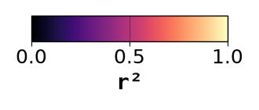

```python
viewer_ld = (
    Tracks(chrom_sizes)
    .add_arc_matrix_track(
        ld, 'LD', chrom='chr1', start=40_000_000, window_size=1_000_000,
        threshold=0.2, palette='magma', vmin=0, vmax=1,
        value_label='r²', height=100, height_by_span=True,
    )
    .add_gene_track(assembly='hg38', height=100)
    .set_viewport('chr1', 35_000_000, 165_000_000)
    .legend('LD')
)
viewer_ld
```

## Tooltip

Each track contributes to the cursor tooltip unless `tip_fmt=False`. Use `tip_fmt` to control what each track contributes to the tooltip. Format placeholders use Python-style `{key}` or `{key:.Nf}` syntax.

Available keys per track type: - **Gene**: `name`, `strand`, `start`, `end` - **Scatter / Line**: `group`, `value`, `x` - **Fill**: `group`, `lo`, `hi`, `x` - **Histogram**: `group`, `value`, `x` - **Segment**: `group` - **Heatmap**: `group`, `individual`, `nInd` - **Arc**: `group`, `pos1`, `pos2`, `span` - **Arc matrix**: `value`, `row`, `col`, `start1`, `end1`, `start2`, `end2`, `pos1`, `pos2`, `span`

If a format string references an invalid key, the tooltip shows the available keys as a hint.

```python
viewer5 = (
    Tracks(chrom_sizes)
    .add_point_track(
        qdf, 'Scatter', x='pos', y='fst', group_by='pop',
        tip_fmt="{value:.4f} is the value for {group}",
    )
    .add_line_track(
        qdf, 'Lines', x='pos', y='rate', group_by='pop',
        tip_fmt="For {group} the value is {value:.2f}",
    )
    .add_gene_track(
        assembly='hg38', height=44,
        tip_fmt="The gene at this pos is {name}",
    )
)
viewer5
```

## Theme

The widget has a light and dark default theme determined by the vscodenb package if installed. You get the active theme defaults like this:

```python
from geneinfo.widget import get_default_theme, set_default_theme
theme = get_default_theme()
theme
```

```
{'bg': '#ffffff',
 'fg': '#1a1a2e',
 'panel': '#ffffff',
 'border': '#ffffff',
 'input_bg': '#ffffff',
 'input_fg': '#1a1a2e',
 'input_border': '#c0c0cc',
 'focus_border': '#3355dd',
 'axis_text': '#888899',
 'track_label': '#555566',
 'gene_exon': '#4488cc',
 'gene_spine': '#666688',
 'gene_label': '#000000',
 'highlight_fill': '#e03a4e',
 'highlight_spine': '#d80ce6',
 'highlight_outline': '#000000',
 'highlight_label': '#169f4a',
 'highlight_halo': '#79CAD32E',
 'sidebar_w': 96}
```

You can change the theme colors and save them back for use in subsequent viewers:

```python
# theme['input_bg'] = 'pink'
set_default_theme(theme)
```